# StudyPipeline

Preprocessing for TRT

This pipeline measures total reading time (TRT) per word AOI per subject using the gctg-clean dataset

[output not shown]

```
INFO:pymovements.dataset.dataset:        You are downloading the gctg dataset. Please be aware that pymovements does not
        host or distribute any dataset resources and only provides a convenient interface to
        download the public dataset resources that were published by their respective authors.
```

```
Using already downloaded and verified file: data-clean\downloads\gctg-data-clean.zip
Extracting gctg-data-clean.zip to data-clean\raw
```

```
Loaded gaze frames: 12
```

```
Stimuli (non-practice): 152 | Subjects: 12 -> ['P01', 'P02', 'P03', 'P04', 'P05', 'P06', 'P07', 'P08', 'P09', 'P10', 'P11', 'P12']
```

```
['prize-pos.interest',
 'voicemail-zero.question',
 'delayed-pos.question',
 'goldfish-zero.difficulty',
 'voicemail-neg.text.3',
 'blackout-zero.text.3',
 'goldfish-zero.question',
 'breakfast-pos.question',
 'blackout-neg.text.3',
 'voicemail-zero.naturalness']
```

```
Loaded AOIs for 152 stimuli. Missing AOIs: 0
```

```
0it [00:00, ?it/s]
```

```
Events detected and fixation locations computed.
```

```
0
```

```
Cached event tables: 555
Saved TRT rows: 36160 -> data-clean\processed\trt_by_word.csv
```

|  | subject_id | stimulus | condition | index | content | total_reading_time |
| --- | --- | --- | --- | --- | --- | --- |
| 0 | P01 | blackout-zero.text.2 | zero | 202 | One | 187 |
| 1 | P01 | blackout-zero.text.2 | zero | 203 | brave | 255 |
| 2 | P01 | blackout-zero.text.2 | zero | 204 | soul, | 0 |
| 3 | P01 | blackout-zero.text.2 | zero | 205 | a | 0 |
| 4 | P01 | blackout-zero.text.2 | zero | 206 | young | 255 |
| 5 | P01 | blackout-zero.text.2 | zero | 207 | woman | 173 |
| 6 | P01 | blackout-zero.text.2 | zero | 208 | named | 102 |
| 7 | P01 | blackout-zero.text.2 | zero | 209 | Sarah, | 135 |
| 8 | P01 | blackout-zero.text.2 | zero | 210 | decided | 165 |
| 9 | P01 | blackout-zero.text.2 | zero | 211 | to | 0 |

# Linguistic Features Pipeline

This pipeline extracts the following linguistic features:

- Word frequency: SUBTLEX-US Zipf scores (lemma-first, then surface)
- Word length: Alphabetic character count
- **Dependency distance: Linear distance to syntactic head (Gibson 2000 locality theory)
- Syntactic tree depth: Distance from token to root
- Integration cost: Locality-based processing difficulty metric

Features are aligned to AOI tokens and merged with TRT data for mixed-effects modeling.

[output not shown]

```
Base directory: c:\a\project\data-clean
SUBTLEX exists: True
TRT data exists: True
```

```
Stimuli to process (from TRT): 152
Subjects: 12
Conditions: ['neg', 'pos', 'zero']
```

```
Loaded AOIs: 152 stimuli
```

```
breakfast-zero.question: 156 chars, first 100: 'What caused the narrator to feel uneasy during breakfast? The coffee tasted bitter The waitress acte'
prize-zero.text.4: 380 chars, first 100: '"I don\'t know if I\'m ready for that," Emily said, feeling a sense of trepidation. The woman smiled. '
breakfast-neg.question: 203 chars, first 100: 'What unexpected event happened to the narrator at the diner? The diner ran out of food. A stranger j'
```

```
Loading spaCy model...
```

```
spaCy pipeline: ['tok2vec', 'tagger', 'parser', 'attribute_ruler', 'lemmatizer']
Test parse: 10 tokens, 1 sentences
```

```
Loading SUBTLEX-US...
SUBTLEX entries: 74286
Sample entries:
         form      zipf
0  sanctimony  1.602060
1      lowest  3.644439
2    unforced  1.301030
3     dirties  2.000000
4       leper  3.093422
```

```
the: 7.469073206544746
cat: 4.821709997298376
quickly: 4.751971574736327
xyzabc: None
```

[output not shown]

[output cut: 99 more lines]

```
Processing 139/152: blackout-neg.text.0
Processing 140/152: goldfish-neg.naturalness
Processing 141/152: blackout-neg.text.1
Processing 142/152: goldfish-neg.text.2
Processing 143/152: breakfast-neg.interest
Processing 144/152: goldfish-pos.question
Processing 145/152: prize-zero.text.0
Processing 146/152: goldfish-neg.difficulty
Processing 147/152: voicemail-neg.text.3
Processing 148/152: voicemail-pos.text.2
Processing 149/152: breakfast-pos.text.3
Processing 150/152: blackout-neg.text.2
Processing 151/152: breakfast-zero.text.2
Processing 152/152: voicemail-zero.interest
Feature extraction complete.
```

```
Saved features: 9905 rows -> data-clean\processed\features_by_word.parquet
Columns: ['stimulus', 'index', 'content', 'word_len', 'freq_zipf', 'dep_dist', 'depth', 'integration_cost', 'dep_label', 'pos_tag', 'lemma', 'sentence_id', 'token_id_sent']
```

```
Merging features with TRT data...
Saved merged data: 36160 rows -> data-clean\processed\trt_with_features.parquet

Null counts in merged data:
freq_zipf: 939/36160 (2.6%)
dep_dist: 102/36160 (0.3%)
depth: 102/36160 (0.3%)
integration_cost: 102/36160 (0.3%)

Final columns: ['subject_id', 'stimulus', 'condition', 'index', 'content', 'total_reading_time', 'word_len', 'freq_zipf', 'dep_dist', 'depth', 'integration_cost', 'dep_label', 'pos_tag', 'lemma', 'sentence_id', 'token_id_sent']
```

```
=== ALIGNMENT COVERAGE REPORT ===
Stimuli with ≥90% token alignment: 152/152

Per-stimulus coverage:
prize-pos.text.0: 95.5% (84/88)
blackout-pos.text.2: 96.3% (79/82)
prize-pos.text.4: 97.0% (32/33)
prize-zero.text.0: 97.3% (108/111)
delayed-pos.text.3: 97.5% (39/40)
breakfast-pos.text.0: 97.7% (85/87)
blackout-pos.text.1: 97.7% (85/87)
breakfast-pos.text.1: 98.3% (113/115)
goldfish-pos.text.0: 98.5% (64/65)
goldfish-pos.text.2: 98.6% (68/69)
prize-pos.text.2: 98.7% (74/75)
prize-pos.text.3: 98.8% (81/82)
breakfast-pos.text.3: 98.8% (84/85)
voicemail-pos.text.1: 98.9% (88/89)
delayed-pos.text.2: 98.9% (88/89)
blackout-pos.text.0: 98.9% (91/92)
delayed-neg.text.0: 99.1% (107/108)
delayed-zero.text.0: 99.1% (107/108)
blackout-zero.text.2: 99.2% (122/123)
breakfast-zero.question: 100.0% (25/25)
prize-zero.text.4: 100.0% (74/74)
breakfast-neg.question: 100.0% (35/35)
delayed-neg.text.1: 100.0% (105/105)
blackout-zero.text.3: 100.0% (123/123)
delayed-pos.interest: 100.0% (23/23)
voicemail-neg.naturalness: 100.0% (27/27)
voicemail-zero.difficulty: 100.0% (27/27)
goldfish-neg.text.1: 100.0% (136/136)
voicemail-pos.text.0: 100.0% (94/94)
breakfast-pos.question: 100.0% (32/32)
voicemail-pos.text.3: 100.0% (67/67)
voicemail-zero.text.3: 100.0% (52/52)
delayed-neg.question: 100.0% (31/31)
goldfish-neg.text.0: 100.0% (115/115)
delayed-neg.text.3: 100.0% (135/135)
breakfast-neg.text.0: 100.0% (106/106)
```

[output cut: 126 more lines]

```
0     punct  1488
1       det   824
2      prep   801
3      pobj   786
4     nsubj   772
5      ROOT   712
6    advmod   590
7      amod   550
8      dobj   497
9       aux   414

Pipeline completed successfully!
Ready for mixed-effects modeling with 36160 observations
Subjects: 12
Conditions: ['neg', 'pos', 'zero']
```

# Mixed-effects pipeline

```
Rows after trimming: 18172
```

|  | total_reading_time | subject_id | stimulus | condition | word_len | freq_zipf | dep_dist | depth | integration_cost | log_trt | word_len_z | freq_zipf_z | dep_dist_z | depth_z | integration_cost_z |
| --- | --- | --- | --- | --- | --- | --- | --- | --- | --- | --- | --- | --- | --- | --- | --- |
| 0 | 187 | P01 | blackout-zero.text.2 | zero | 3 | 6.487455 | 2 | 2 | 1.0 | 5.231109 | -0.911924 | 0.796754 | -0.129824 | -0.110513 | -0.123215 |
| 1 | 255 | P01 | blackout-zero.text.2 | zero | 5 | 4.501196 | 1 | 2 | 0.6 | 5.541264 | -0.085272 | -0.653453 | -0.470300 | -0.110513 | -0.394412 |
| 4 | 255 | P01 | blackout-zero.text.2 | zero | 5 | 5.385928 | 1 | 3 | 0.6 | 5.541264 | -0.085272 | -0.007493 | -0.470300 | 0.550312 | -0.394412 |

```
=== MixedLM (crossed intercepts) ===
               Mixed Linear Model Regression Results
====================================================================
Model:                 MixedLM    Dependent Variable:    log_trt
No. Observations:      18172      Method:                REML
No. Groups:            12         Scale:                 0.1885
Min. group size:       902        Log-Likelihood:        -11022.9610
Max. group size:       2001       Converged:             Yes
Mean group size:       1514.3
--------------------------------------------------------------------
                         Coef.  Std.Err.    z    P>|z| [0.025 0.975]
--------------------------------------------------------------------
Intercept                 5.724    0.027 209.251 0.000  5.670  5.777
C(condition, Sum)[S.neg] -0.011    0.011  -0.979 0.327 -0.032  0.011
C(condition, Sum)[S.pos]  0.024    0.011   2.182 0.029  0.002  0.045
freq_zipf_z              -0.048    0.005  -9.699 0.000 -0.057 -0.038
word_len_z                0.085    0.005  17.442 0.000  0.076  0.095
dep_dist_z               -0.008    0.005  -1.532 0.126 -0.018  0.002
depth_z                   0.012    0.003   3.703 0.000  0.006  0.019
integration_cost_z        0.000    0.005   0.068 0.946 -0.010  0.010
subject_id Var            0.008    0.009
stimulus Var              0.020    0.005
====================================================================
```

```
=== MixedLM (subject slopes: freq, length) + item VC ===
                 Mixed Linear Model Regression Results
========================================================================
Model:                 MixedLM      Dependent Variable:      log_trt
No. Observations:      18172        Method:                  REML
No. Groups:            12           Scale:                   0.1860
Min. group size:       902          Log-Likelihood:          -10921.4339
Max. group size:       2001         Converged:               Yes
Mean group size:       1514.3
------------------------------------------------------------------------
                             Coef.  Std.Err.    z    P>|z| [0.025 0.975]
------------------------------------------------------------------------
Intercept                     5.729    0.029 200.058 0.000  5.672  5.785
C(condition, Sum)[S.neg]     -0.014    0.011  -1.257 0.209 -0.035  0.008
C(condition, Sum)[S.pos]      0.028    0.011   2.583 0.010  0.007  0.050
freq_zipf_z                  -0.054    0.014  -3.920 0.000 -0.082 -0.027
word_len_z                    0.089    0.012   7.699 0.000  0.067  0.112
dep_dist_z                   -0.008    0.005  -1.541 0.123 -0.018  0.002
depth_z                       0.013    0.003   3.943 0.000  0.007  0.020
integration_cost_z            0.000    0.005   0.059 0.953 -0.010  0.010
subject_id Var                0.009    0.010
subject_id x freq_zipf_z Cov -0.003    0.004
freq_zipf_z Var               0.002    0.002
subject_id x word_len_z Cov   0.003    0.003
freq_zipf_z x word_len_z Cov -0.001    0.002
word_len_z Var                0.001    0.002
stimulus Var                  0.020    0.005
========================================================================
```

```
Chosen model: slopes
Saved: mixedlm_fixed_effects_chosen.csv, mixedlm_choice.json
Saved: mixedlm_obs_vs_fitted.png, mixedlm_residuals_hist.png
```

# Condition effects analysis

```
Saved: data-clean\processed\condition_marginal_means.csv | data-clean\processed\condition_pairwise_contrasts.csv

Marginal means (%):
   condition  pct_mean  pct_ci_lo  pct_ci_hi
0       neg  30236.92   28475.85   32106.53
1       pos  31533.91   29679.86   33503.39
2      zero  30204.45   28449.23   32067.59

Pairwise contrasts (%):
      contrast  pct_diff  pct_ci_lo  pct_ci_hi
0   neg - pos     -4.10      -7.62      -0.45
1  neg - zero      0.11      -3.42       3.77
2  pos - zero      4.39       0.66       8.25
```

# Linguistic feature differences across gaze conditions

- Describes how features (frequency, length, dependency distance, depth, integration cost) differ by condition (neg/zero/pos).

```
Conditions: ['neg', 'pos', 'zero']
Rows: 18172 | Subjects: 12 | Stimuli: 152
Setup complete.
```

```
Saved descriptive stats -> data-clean\processed\feature_condition_descriptives.csv
```

[output not shown]

```
Saved boxplots to data-clean\processed
```

```
C:\Users\Mert Yeşilyurt\AppData\Local\Temp\ipykernel_9560\2890229590.py:16: MatplotlibDeprecationWarning: The 'labels' parameter of boxplot() has been renamed 'tick_labels' since Matplotlib 3.9; support for the old name will be dropped in 3.11.
  ax.boxplot(data, labels=['neg','zero','pos'], showfliers=False)
```

```
[OK] freq_zipf model fit; saved -> data-clean\processed\feature_mixedlm_freq_zipf.csv
```

```
[OK] word_len model fit; saved -> data-clean\processed\feature_mixedlm_word_len.csv
```

```
[OK] dep_dist model fit; saved -> data-clean\processed\feature_mixedlm_dep_dist.csv
```

```
[OK] depth model fit; saved -> data-clean\processed\feature_mixedlm_depth.csv
```

```
[OK] integration_cost model fit; saved -> data-clean\processed\feature_mixedlm_integration_cost.csv
Saved combined feature~condition summary -> data-clean\processed\feature_condition_mixedlm_summary.csv
```

```
Saved TRT condition effect tables (with/without features).
```

Done. Outputs are saved under `data-clean/processed/`:

- `feature_condition_descriptives.csv`
- `feature_boxplot_*.png`
- `feature_mixedlm_*.csv` and combined `feature_condition_mixedlm_summary.csv`
- `trt_condition_effects_without_features.csv` and `trt_condition_effects_with_features.csv` (if successful)

Reports

1. Main Research Question: Effects of lexical/syntactic features on log(TRT).
2. Secondary RQ: Feature differences across conditions.
3. Secondary RQ: TRT differences across conditions.

```
fe_validation: True -> data-clean\processed\mixedlm_fe_summary_validation.csv
fe_chosen: True -> data-clean\processed\mixedlm_fixed_effects_chosen.csv
cond_means: True -> data-clean\processed\condition_marginal_means.csv
cond_contrasts: True -> data-clean\processed\condition_pairwise_contrasts.csv
feat_desc: True -> data-clean\processed\feature_condition_descriptives.csv
feat_mixed: True -> data-clean\processed\feature_condition_mixedlm_summary.csv
Setup complete.
```

|  | label | percent | percent_lo | percent_hi | beta | ci_lo | ci_hi |
| --- | --- | --- | --- | --- | --- | --- | --- |
| 0 | Dependency distance | -0.783611 | -1.771351 | 0.214061 | -0.007867 | -0.017872 | 0.002138 |
| 1 | Frequency (Zipf) | -5.290908 | -7.830629 | -2.681206 | -0.054360 | -0.081542 | -0.027178 |
| 2 | Integration cost | 0.030052 | -0.962779 | 1.032836 | 0.000300 | -0.009674 | 0.010275 |
| 3 | Syntactic depth | 1.329408 | 0.666388 | 1.996795 | 0.013206 | 0.006642 | 0.019771 |
| 4 | Word length | 9.356613 | 6.894830 | 11.875092 | 0.089444 | 0.066675 | 0.112213 |

|  | feature | condition | coef | ci_lo | ci_hi |
| --- | --- | --- | --- | --- | --- |
| 0 | dep_dist | neg | 0.025457 | 0.004831 | 0.046083 |
| 1 | dep_dist | pos | -0.014373 | -0.035691 | 0.006946 |
| 2 | depth | neg | 0.143050 | 0.111763 | 0.174338 |
| 3 | depth | pos | -0.129509 | -0.161418 | -0.097599 |
| 4 | freq_zipf | neg | 0.324625 | 0.299413 | 0.349837 |
| 5 | freq_zipf | pos | -0.431886 | -0.458376 | -0.405396 |
| 6 | integration_cost | neg | 0.049957 | 0.028674 | 0.071240 |
| 7 | integration_cost | pos | -0.046412 | -0.068561 | -0.024263 |
| 8 | word_len | neg | -0.305453 | -0.332644 | -0.278262 |
| 9 | word_len | pos | 0.398906 | 0.370695 | 0.427117 |

| condition feature | neg | zero | pos |
| --- | --- | --- | --- |
| dep_dist | 2.449349 | 2.347391 | 2.339787 |
| depth | 2.401642 | 2.138148 | 1.926000 |
| freq_zipf | 5.828690 | 5.524684 | 4.747110 |
| integration_cost | 1.252029 | 1.174212 | 1.108051 |
| word_len | 4.468247 | 5.013411 | 6.284422 |

```
(  condition      pct_mean     pct_ci_lo     pct_ci_hi
 0       neg  30236.921236  28475.847295  32106.526742
 1       pos  31533.910959  29679.860224  33503.392192
 2      zero  30204.454268  28449.232400  32067.588103,
      contrast  pct_diff  pct_ci_lo  pct_ci_hi
 0   neg - pos -4.099998  -7.615254  -0.450986
 1  neg - zero  0.107136  -3.423179   3.766500
 2  pos - zero  4.387001   0.661835   8.250023)
```

```
Saved figure -> data-clean\processed\report_fig_feature_effects.png
```

```
Saved figure -> data-clean\processed\report_fig_condition_means.png
```

Outputs written under `data-clean/processed/`:

- Tables: `report_main_feature_effects.csv`, `report_feature_condition_effects.csv`, `report_feature_condition_descriptives_wide.csv`, `report_condition_marginal_means.csv`, `report_condition_pairwise_contrasts.csv`
- Figures: `report_fig_feature_effects.png`, `report_fig_condition_means.png`

## Final figures (visible)

Below are the only figures displayed in this notebook:

All plots use relative paths and are saved under `data-clean/processed/` for reuse.

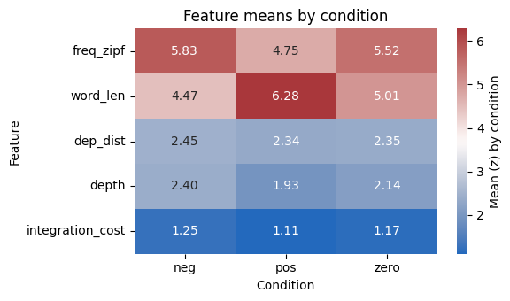

```
Saved heatmap -> data-clean\processed\report_fig_feature_means_heatmap.png
```

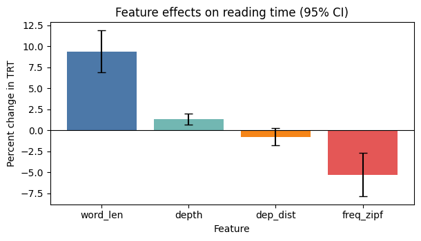

```
Saved feature effects -> data-clean\processed\report_fig_feature_effects.png
```

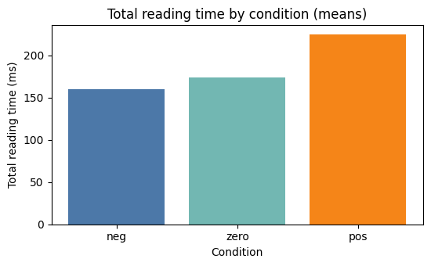

```
Saved condition means -> data-clean\processed\report_fig_condition_means.png
```